# SDS/CSC 293 Mini-Project 3: Multiple Regression

Group 1: Bushra T. and Tina L.

Wednesday, March 27<sup>th</sup>, 2019

You will be submiting an entry to Kaggle’s [DonorsChoose.org Application Screening: Predict whether teachers’ project proposals are accepted](https://www.kaggle.com/c/donorschoose-application-screening/) by fitting a **logistic regression** model $\hat{f}(x)$.

# EDA

Read in data provided by Kaggle for this competition. They are organized in the `data/` folder of this RStudio project:

```r
training <- read_csv("data/train.csv")
test <- read_csv("data/test.csv")
sample_submission <- read_csv("data/sample_submission.csv")
```

Before performing any model fitting, you should always conduct an exploratory data analysis. This will help guide and inform your model fitting.

## Look at your data!

Always, ALWAYS, **ALWAYS** start by looking at your raw data. This gives you visual sense of what information you have to help build your predictive models. To get a full description of each variable, read the data dictionary in the `data_description.txt` file in the `data/` folder.

Note that the following code chunk has `eval = FALSE` meaning “don’t evaluate this chunk with knitting” because `.Rmd` files won’t knit if they include a `View()`:

```r
View(training)
glimpse(training)

View(test)
glimpse(test)
```

In particular, pay close attention to the variables and variable types in the `sample_submission.csv`. Your submission must match this exactly.

```r
glimpse(sample_submission)
```

```
## Observations: 78,035
## Variables: 2
## $ id                  <chr> "p233245", "p096795", "p236235", "p233680", …
## $ project_is_approved <dbl> 0.8476823, 0.8476823, 0.8476823, 0.8476823, …
```

## Data wrangling

As much as possible, try to do all your data wrangling here:

```r
training <- training %>%
  mutate(truth = factor(project_is_approved, levels = c(1, 0)),
         project_grade_category = factor(project_grade_category, levels = c("Grades PreK-2", "Grades 3-5", "Grades 6-8", "Grades 9-12")))
```

# Minimally viable product

## Fit model on training

Fit a logistic regression model $\widehat{f}_1$ with only an intercept term on all the training data. In other words, your model will not use any predictor variables. Save this in `model_1`. What is the uniquely fitted probability?

```r
model_1 <- glm(project_is_approved~1, "binomial", training)
```

## Estimate of your Kaggle score

Use the `yardstick` package to get an estimate of your Kaggle score: the area under the ROC curve (AUC). Crossvalidation is not necessary as with no predictor variables, we are in very little danger of overfitting the model.

```r
training_model_1 <- model_1 %>%
  broom::augment(newdata = training, type.predict = "response")

training_model_1 %>%
  roc_auc(truth, .fitted)
```

| .metric | .estimator | .estimate |
| --- | --- | --- |
| roc_auc | binary | 0.5 |

[^1](https://thomasleeper.com/Rcourse/Tutorials/binaryglmplots.html) The estimate of our Kaggle score is 0.5.

## Make predictions on test

Apply your `model_1` fitted model to the test data. What is the uniquely predicted probability?

```r
test_model_1 <- model_1 %>%
  broom::augment(newdata = test, type.predict = "response")

unique(test_model_1$.fitted)
```

```
## [1] 0.8476823
```

The uniquely predicted probability is ~0.8477!

## Create your submission CSV

```r
sample_submission %>%
  mutate(project_is_approved = 0.848) %>%
  write_csv(path = "data/submission_model_1.csv")
```

## Screenshot of your Kaggle score

Our score based on our submission’s “Area under the Receiver Operating Characteristic Curve” was 0.5.

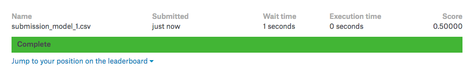

# Due diligence

## Plot ROC curve

Use the `yardstick` package to plot the ROC curve:

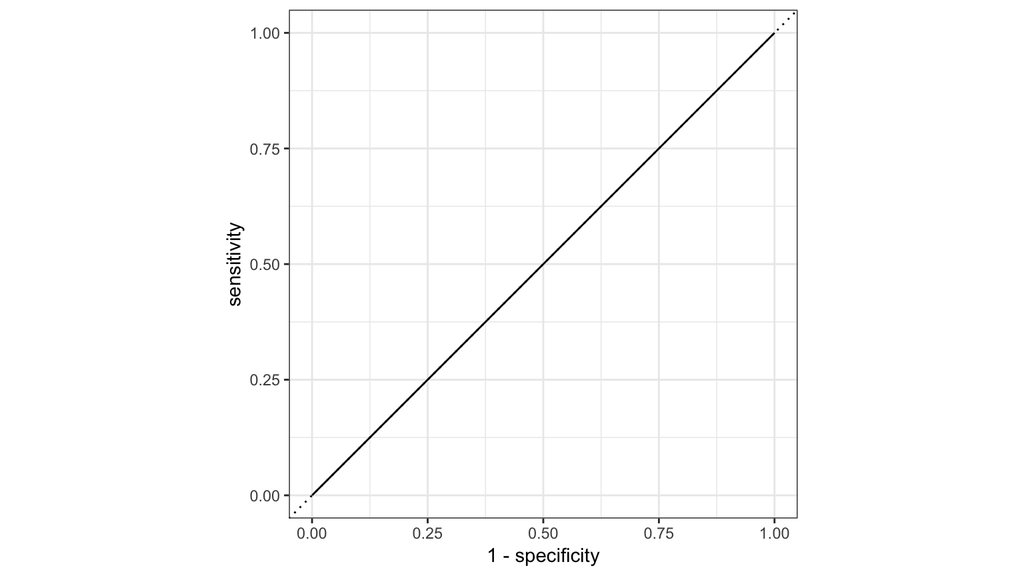

```r
training_model_1 %>%
  roc_curve(truth, .fitted) %>%
  autoplot()
```

# Reaching for the stars

## Fit model on training

Fit a logistic regression model $\widehat{f}_2$ using a single numerical predictor variable $x$ on all the training data. Save this in `model_2`. Then display a single visualization that shows:

- The relationship between outcome variable $y$ and your numerical predictor variable $x$ with black points
- The relationship between the fitted probabilities $\widehat{p}$ from model $\widehat{f}_2$ and your numerical predictor variable $x$ with a red curve
- The fitted probabilities $\widehat{p}$ from model $\widehat{f}_1$ with a horizontal blue line

at the same time.

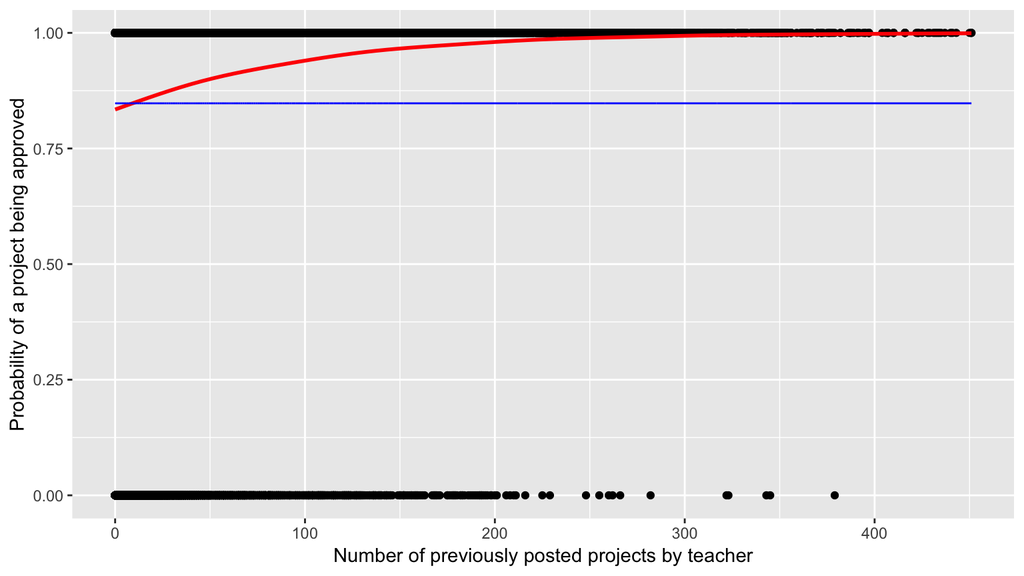

```r
model_2 <- glm(project_is_approved~teacher_number_of_previously_posted_projects, "binomial", training)

training_model_2 <- model_2 %>%
  broom::augment(newdata = training, type.predict = "response")

ggplot(training_model_2) +
  geom_point(aes(x = teacher_number_of_previously_posted_projects, y = project_is_approved)) +
  geom_smooth(aes(x = teacher_number_of_previously_posted_projects, y = .fitted), color = "red") +
  geom_line(data = training_model_1, aes(x = teacher_number_of_previously_posted_projects, y = .fitted), color = "blue") +
  labs(x = "Number of previously posted projects by teacher", y = "Probability of a project being approved")
```

## Estimate of your Kaggle score

Use the `yardstick` package to get an estimate of your Kaggle score: the area under the ROC curve (AUC). Crossvalidation is not necessary as with only 1 predictor variable and so many points, we are in very little danger of overfitting the model.

```r
training_model_2 %>%
  roc_auc(truth, .fitted)
```

| .metric | .estimator | .estimate |
| --- | --- | --- |
| roc_auc | binary | 0.5607127 |

The estimate of our Kaggle score is ~0.561.

## Make predictions on test

Apply your `model_2` fitted model to the test data and display a histogram of the predicted probabilities.

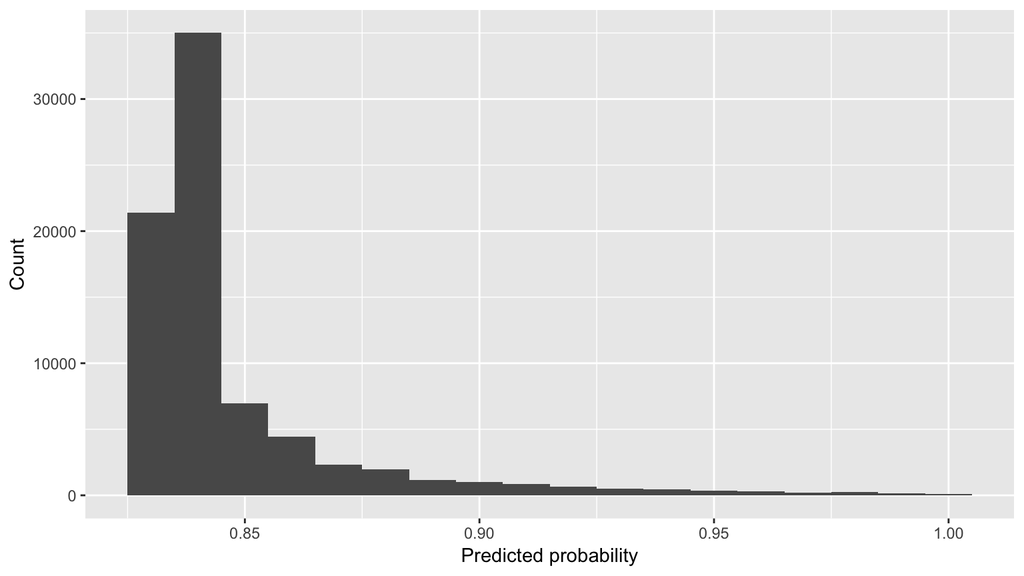

```r
test_model_2 <- model_2 %>%
  broom::augment(newdata = test, type.predict = "response")

ggplot(test_model_2, aes(.fitted)) +
  geom_histogram(binwidth = 0.01) +
  labs(x = "Predicted probability", y = "Count")
```

## Create your submission CSV

```r
sample_submission %>%
  mutate(project_is_approved = test_model_2$.fitted) %>%
  write_csv(path = "data/submission_model_2.csv")
```

## Screenshot of your Kaggle score

Our score based on our submission’s “Area under the Receiver Operating Characteristic Curve” was 0.56522.

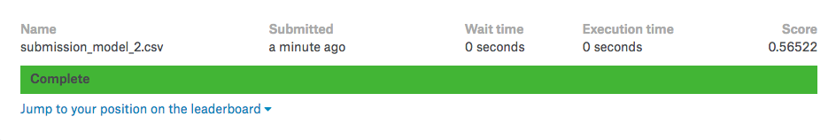

## Plot ROC curve

Use the `yardstick` package to plot the ROC curve:

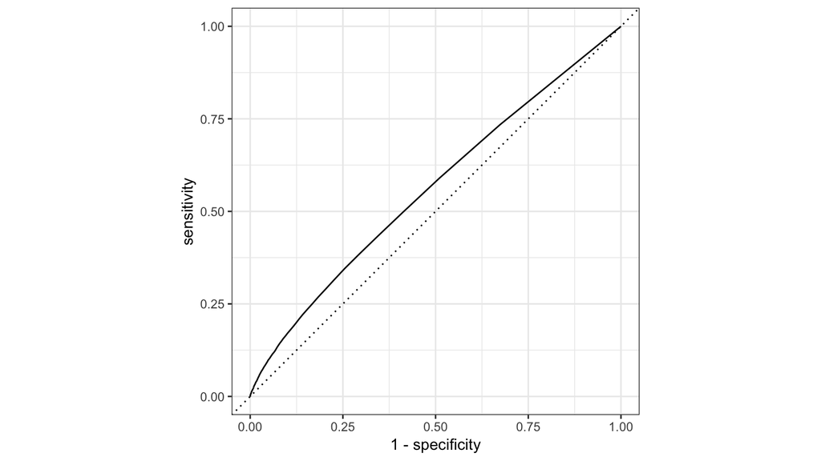

```r
training_model_2 %>%
  roc_curve(truth, .fitted) %>%
  autoplot()
```

# Point of diminishing returns

## Fit model on training

Fit a logistic regression model $\widehat{f}_3$ using a single categorical predictor variable $x$ on all the training data. Save this in `model_3`. Then display a single visualization that shows:

- The relationship between the fitted probabilities $\widehat{p}$ from model $\widehat{f}_3$ and your categorical predictor variable $x$
- The fitted probabilities $\widehat{p}$ from model $\widehat{f}_1$ with a horizontal blue line

at the same time.

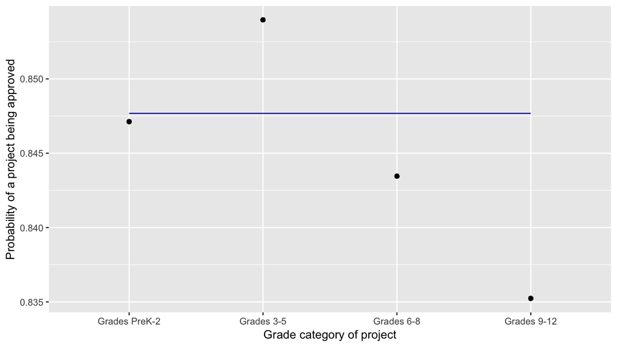

```r
model_3 <- glm(project_is_approved~project_grade_category, "binomial", training)

training_model_3 <- model_3 %>%
  broom::augment(newdata = training, type.predict = "response")

ggplot() +
  geom_point(data = training_model_3, aes(x = project_grade_category, y = .fitted)) +
  geom_line(data = training_model_1, aes(x = project_grade_category, y = .fitted, group = 1), color = "blue") +
  labs(x = "Grade category of project", y = "Probability of a project being approved")
```

## Estimate of your Kaggle score

Use the `yardstick` package to get an estimate of your Kaggle score: the area under the ROC curve (AUC). Crossvalidation is not necessary as with only 1 predictor variable and so many points, we are in very little danger of overfitting the model.

```r
training_model_3 %>%
  roc_auc(truth, .fitted)
```

| .metric | .estimator | .estimate |
| --- | --- | --- |
| roc_auc | binary | 0.5115242 |

The estimate of our Kaggle score is 0.512.

## Make predictions on test

Apply your `model_3` fitted model to the test data and display a histogram of the predicted probabilities.

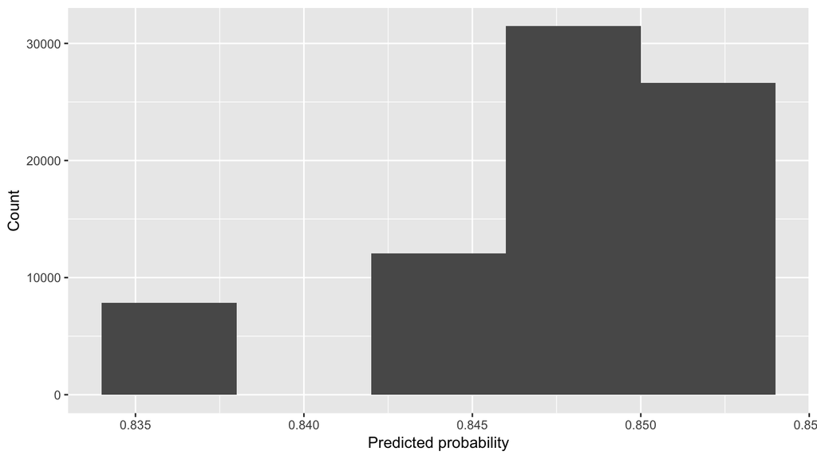

```r
test_model_3 <- model_3 %>%
  broom::augment(newdata = test, type.predict = "response")

ggplot(test_model_3, aes(.fitted)) +
  geom_histogram(binwidth = 0.004) +
  labs(x = "Predicted probability", y = "Count")
```

## Create your submission CSV

```r
sample_submission %>%
  mutate(project_is_approved = test_model_3$.fitted) %>%
  write_csv(path = "data/submission_model_3.csv")
```

## Screenshot of your Kaggle score

Our score based on our submission’s “Area under the Receiver Operating Characteristic Curve” was 0.51156.

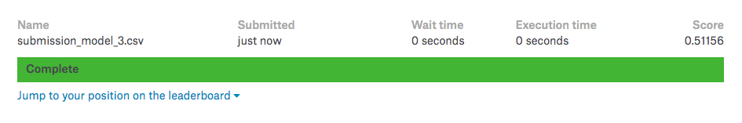

## Plot ROC curve

Use the `yardstick` package to plot the ROC curve:

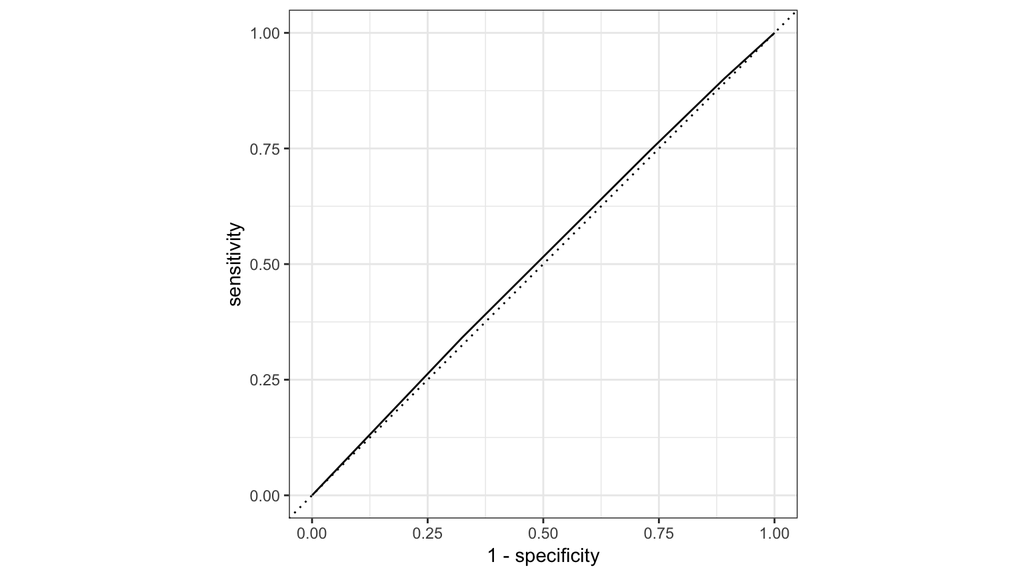

```r
training_model_3 %>%
  roc_curve(truth, .fitted) %>%
  autoplot()
```

# Polishing the cannonball

## Fit model on training

- The relationship between the fitted probabilities $\widehat{p}$ from model $\widehat{f}_3$ and your predictor variables
- The fitted probabilities $\widehat{p}$ from model $\widehat{f}_1$ with a horizontal blue line

at the same time.

```r
model_4 <- glm(project_is_approved~project_subject_categories+project_grade_category+school_state+teacher_prefix+teacher_number_of_previously_posted_projects, "binomial", training)

training_model_4 <- model_4 %>%
  broom::augment(newdata = training, type.predict = "response")
```

For this model, we are using four categorical predictor variables, `project_subject_categories`, `project_grade_category`, `school_state`, `teacher_prefix`, and one numerical predictor variable, `teacher_number_of_previously_posted_projects`.

## Estimate of your Kaggle score

Use the `yardstick` package to get an estimate of your Kaggle score: the area under the ROC curve (AUC).

```r
training_model_4 %>%
  roc_auc(truth, .fitted)
```

| .metric | .estimator | .estimate |
| --- | --- | --- |
| roc_auc | binary | 0.5896406 |

## Make predictions on test

Apply your `model_4` fitted model to the test data and display a histogram of the predicted probabilities.

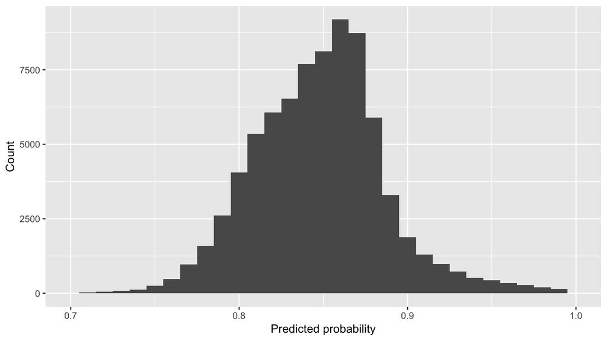

```r
test_model_4 <- model_4 %>%
  broom::augment(newdata = test, type.predict = "response")

ggplot(test_model_4, aes(.fitted)) +
  geom_histogram(binwidth = 0.01) +
  scale_x_continuous(limits = c(0.7, 1)) +
  labs(x = "Predicted probability", y = "Count")
```

## Create your submission CSV

```r
sample_submission %>%
  mutate(project_is_approved = ifelse(is.na(test_model_4$.fitted), 0.8477, test_model_4$.fitted)) %>%
  write_csv(path = "data/submission_model_4.csv")
```

## Screenshot of your Kaggle score

Our score based on our submission’s “Area under the Receiver Operating Characteristic Curve” was 0.58820.

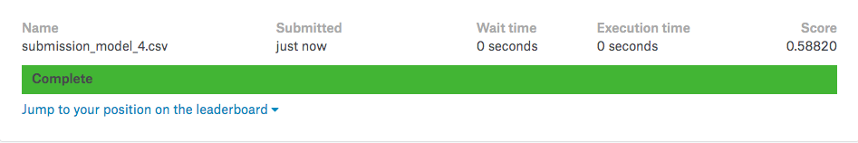

## Plot ROC curve

Use the `yardstick` package to plot the ROC curve:

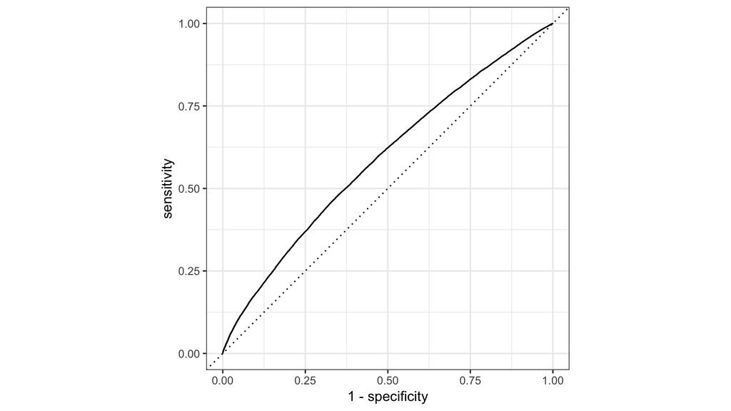

```r
training_model_4 %>%
  roc_curve(truth, .fitted) %>%
  autoplot()
```

[^1]: We use `type.predict = "response"` as we want the predicted probabilities, not the default log-odds [predictions.]